# final_proj

christian otto

5/21/2019

I decided to probe a database on suicide numbers to see if there was any correlation between suicide rate and gdp per capita. Of course, correlation is just that: correlation - not cause, and, as this site goes over in more detail, suicide is a VERY complex issue: https://ourworldindata.org/suicide

I have no dreams of nailing down suicide to a single predictor, but let’s see what relationships might exist, and hopefully learn some along the way.

The dataset I’ll use is available for download here: https://www.kaggle.com/russellyates88/suicide-rates-overview-1985-to-2016 It’ll download as a file with a “.csv” at the end. Don’t worry about that, it’s just a general form used to store datasets. You can get more info on it here: https://www.lifewire.com/csv-file-2622708

First off, packages. They provide functions and datasets to us. We’ll just use the function part of these. They’ll make our lives easier by doing things for us. For more info on them you can go here: https://www.datacamp.com/community/tutorials/r-packages-guide

On the first line, we’ll load the tidyverse by using the command “library(tidyverse)”. Of course, you’ll have to make sure you have it installed first. You can do that in rstudio by going to the console and typing “install.packages(tidyverse)”. The tidyverse is a bunch of packages designed to work together that you can load at once. For more info on it you can go here: https://www.tidyverse.org

Next, start by thinking of a name for the database. I used “suicide_df”. Then we’ll load the database by using the read_csv function. Just pass in the file path to your csv file from the directory your in and then store it in the name you picked by putting the “<-” command between the two.

Then we print the first couple rows of the database by passing the database name to the head function. Make sure it looks like mine does below. And for the read_csv function or any of the function I use below, go to this website if you want more info: https://www.rdocumentation.org/packages/plyr/versions/1.8.4/topics/rename

```r
library(tidyverse)
suicide_df <- read_csv("suicide.csv")
head(suicide_df)
```

```
## # A tibble: 6 x 12
##   country  year sex   age   suicides_no population `suicides/100k …
##   <chr>   <dbl> <chr> <chr>       <dbl>      <dbl>            <dbl>
## 1 Albania  1987 male  15-2…          21     312900             6.71
## 2 Albania  1987 male  35-5…          16     308000             5.19
## 3 Albania  1987 fema… 15-2…          14     289700             4.83
## 4 Albania  1987 male  75+ …           1      21800             4.59
## 5 Albania  1987 male  25-3…           9     274300             3.28
## 6 Albania  1987 fema… 75+ …           1      35600             2.81
## # … with 5 more variables: `country-year` <chr>, `HDI for year` <dbl>,
## #   `gdp_for_year ($)` <dbl>, `gdp_per_capita ($)` <dbl>, generation <chr>
```

Now it’s time to get this database to look like how we want it to. By using rename we get ride of the ‘($)’ at the end of ‘gdp_per_capita ($)’, since that’ll be annoying to type everytime. Then, for the same reason, we we get rid of ‘pop’ at then end of ‘suicides/100k pop’.

```r
suicide_df <- suicide_df %>% rename('gdp_per_capita' = 'gdp_per_capita ($)' , 'suicide/100k' = 'suicides/100k pop') %>%
  select("country","year","sex","age","suicide/100k","gdp_per_capita", "suicides_no", "population")
head(suicide_df)
```

```
## # A tibble: 6 x 8
##   country  year sex   age   `suicide/100k` gdp_per_capita suicides_no
##   <chr>   <dbl> <chr> <chr>          <dbl>          <dbl>       <dbl>
## 1 Albania  1987 male  15-2…           6.71            796          21
## 2 Albania  1987 male  35-5…           5.19            796          16
## 3 Albania  1987 fema… 15-2…           4.83            796          14
## 4 Albania  1987 male  75+ …           4.59            796           1
## 5 Albania  1987 male  25-3…           3.28            796           9
## 6 Albania  1987 fema… 75+ …           2.81            796           1
## # … with 1 more variable: population <dbl>
```

This dataset separates the data by year and by age. We’re just worried by the overall trends for now, so we need to get it so that each year only appears once for each country, and we also want the total population and suicide numbers for that year.

To do that we’ll use the group_by function to group this dataset by country and then further by year, so that any function we perform is performed individually on each of these groups. We pass these functions to the summarize function. We’ll use the sum function on the suicides_no column and on the population column. Now we want to get the gpd_per_capita, but that’s already calculated annually. There’s a few ways to get it to the new table, but we’ll just sum up the gdp_per_capita for that country and year, and then divide by the number of rows we just summed. That’ll get us the original value since all the gdp_per_capita values are the same for the same country and year.

```r
suicide_by_year_df <- suicide_df %>%
  group_by(country, year) %>%
  summarize(suicide_no = sum(suicides_no), population = sum(population), gdp_per_capita = sum(gdp_per_capita)/n()) %>%
  ungroup()
head(suicide_by_year_df)
```

```
## # A tibble: 6 x 5
##   country  year suicide_no population gdp_per_capita
##   <chr>   <dbl>      <dbl>      <dbl>          <dbl>
## 1 Albania  1987         73    2709600            796
## 2 Albania  1988         63    2764300            769
## 3 Albania  1989         68    2803100            833
## 4 Albania  1992         47    2822500            251
## 5 Albania  1993         73    2807300            437
## 6 Albania  1994         50    2849300            697
```

Now we want to calculate the percent of people that commit suicide for every country and for every year. You can see that calculation in the first argument to mutate. That function will add a new column with the results. Then we want the percent of people who commit suicide for every 100 gdp per capita

```r
suicide_by_year_df <- suicide_by_year_df %>%
  mutate(suicide_percentage = suicide_no / population * 100, suicide_percent_per_100gdppc = suicide_percentage/gdp_per_capita * 100)
head(suicide_by_year_df)
```

```
## # A tibble: 6 x 7
##   country  year suicide_no population gdp_per_capita suicide_percent…
##   <chr>   <dbl>      <dbl>      <dbl>          <dbl>            <dbl>
## 1 Albania  1987         73    2709600            796          0.00269
## 2 Albania  1988         63    2764300            769          0.00228
## 3 Albania  1989         68    2803100            833          0.00243
## 4 Albania  1992         47    2822500            251          0.00167
## 5 Albania  1993         73    2807300            437          0.00260
## 6 Albania  1994         50    2849300            697          0.00175
## # … with 1 more variable: suicide_percent_per_100gdppc <dbl>
```

Now we’re all ready to start plotting the data to get an idea of what we’re working with. We do that by using the ggplot function. Info on how to use that is on that rdocumentation website. Here it is again: https://www.rdocumentation.org/

On the x-axis we’ll have the gdp_per_capita and on the y-axis we’ll have the suicide_percentage. Each dot will represent an observation. The line running through the points will try to establish a linear relationship between the two variables as best it can.

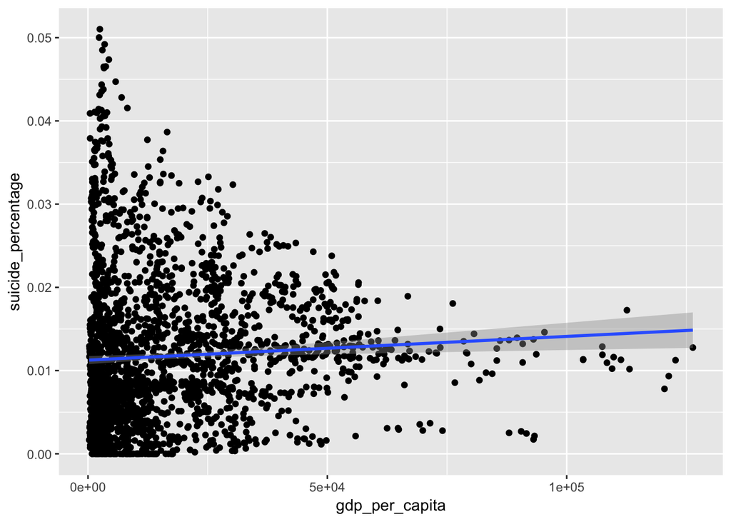

```r
suicide_by_year_df %>% ggplot(aes(x = gdp_per_capita, y = suicide_percentage)) + geom_point() + geom_smooth(method=lm)
```

Just by the spread, you’d think we’d have a roughly inverse relationship between the percent of a population committing suicide and the gdp_per_capita, but the linear regression line reveals that there might be a slightly positive linear relationship between the two or maybe no relationship at all.There’s clearly more dots near the left end of the x-axis, so to get a better look at how gdp_per_capita is distributed we’ll use a histogram.

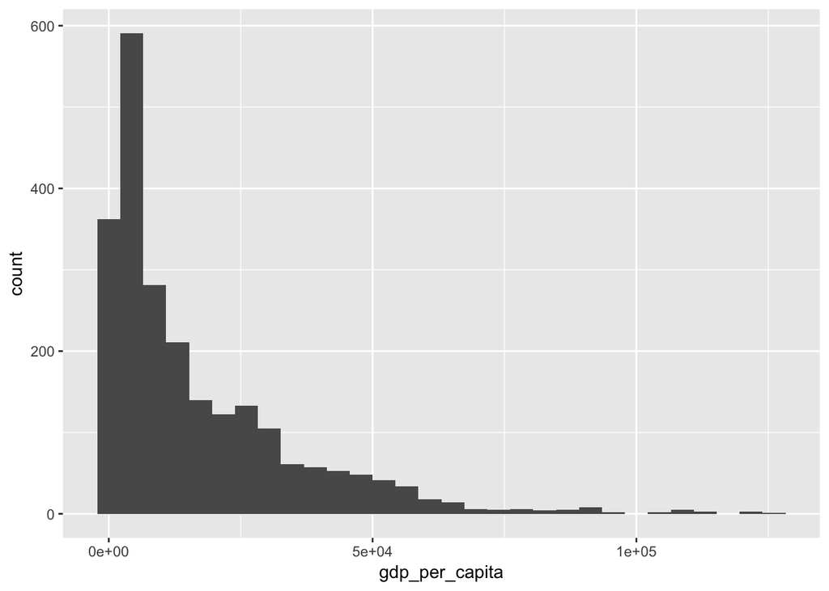

```r
suicide_by_year_df %>% ggplot(aes(x = gdp_per_capita)) + geom_histogram()
```

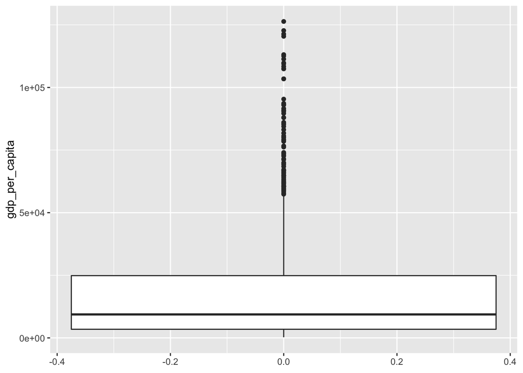

```r
suicide_by_year_df %>% ggplot(aes(y = gdp_per_capita)) + geom_boxplot()
```

The dots represent outliers, the black horizontal line represents the median (the value in the middle if you lined up all values from least to greatest), and the box represents the inter-quartile range (where the middle half fall). Next we’ll due the same thing we did before, where where we plotted gdp_per_capita vs. suicide_percentage, but we’ll do for individual years, starting in 1990 and then for every 5 years after up to 2015.

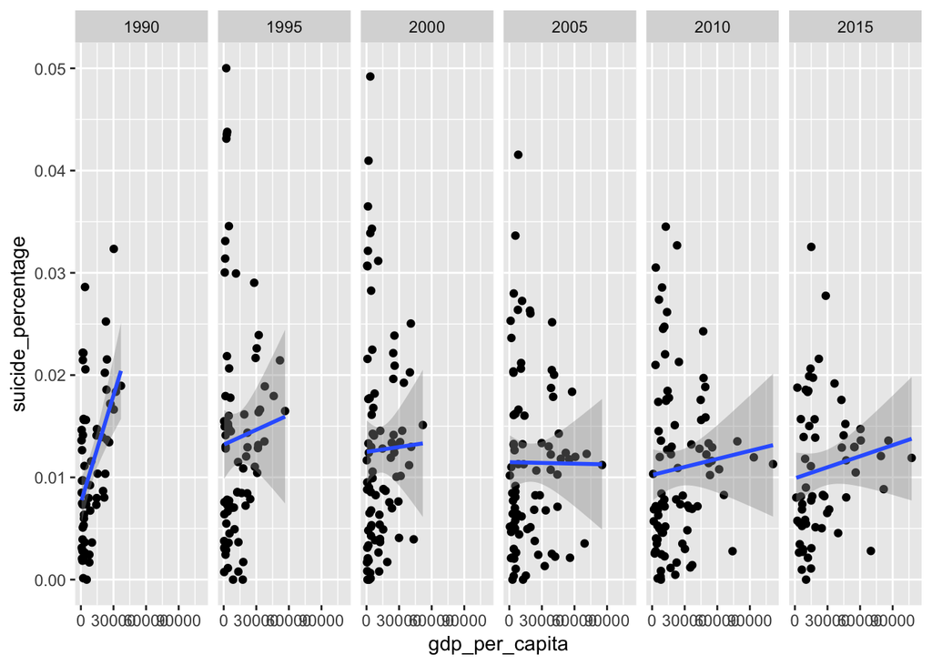

```r
suicide_by_year_df %>% filter(year %in% c("1990","1995", "2000", "2005","2010","2015")) %>%
  ggplot(aes(x=gdp_per_capita, y=suicide_percentage)) +
  facet_grid("year") +
  geom_point() +
  geom_smooth(method=lm)
```

So there’s some obvious variability in the linear regression line. But on average, it’s definitely got a positive slope.

Now we’ll plot gdp_per_capita across time followed by suicide percentage across time, to get an idea of how they might relate.

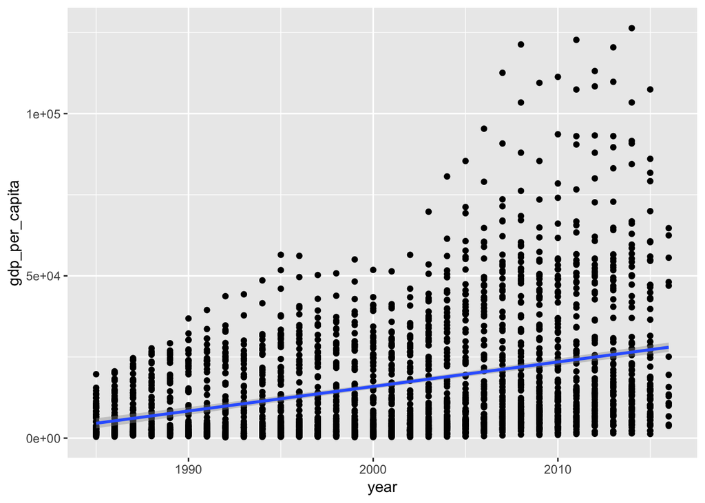

```r
suicide_by_year_df %>% ggplot(aes(x = year, y = gdp_per_capita)) + geom_point() + geom_smooth(method=lm)
```

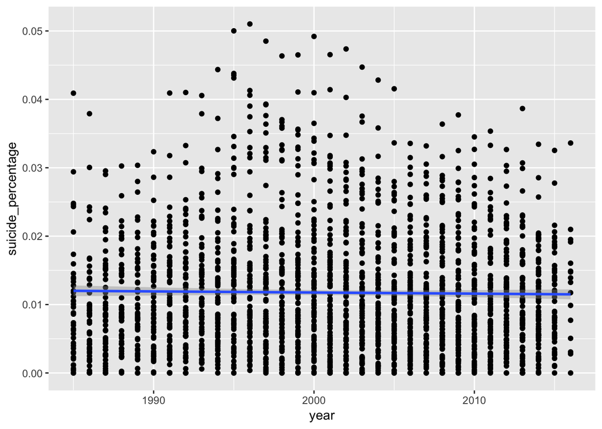

```r
suicide_by_year_df %>% ggplot(aes(x = year, y = suicide_percentage)) + geom_point() + geom_smooth(method=lm)
```

This contradicts the claim that there’s a relationship between gdp per capita and suicide rates, since, on average, gdp steadily climbed while suicide percentage stayed constant. Next, we’ll plot year vs. suicide rate per 100gdppc. This will give us an idea of how they’re relationship has changed over time

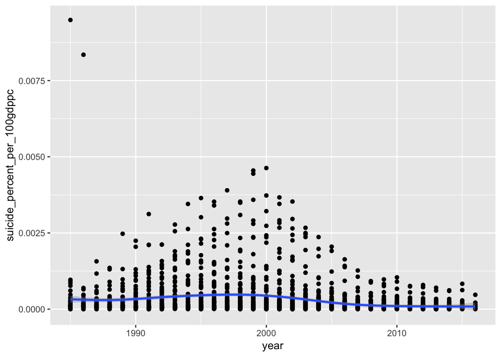

```r
suicide_by_year_df %>% ggplot(aes(x = year, y = suicide_percent_per_100gdppc)) + geom_point() + geom_smooth()
```

So not much change at all. If anything a decrease. Now we’ll move to actually fitting a linear model on the data. We’ll try to predict suicide percentage based on the gdp_per_capita

```r
lin_fit <- lm(suicide_percentage~gdp_per_capita, data=suicide_by_year_df)
lin_fit
```

```
##
## Call:
## lm(formula = suicide_percentage ~ gdp_per_capita, data = suicide_by_year_df)
##
## Coefficients:
##    (Intercept)  gdp_per_capita
##      1.126e-02       2.850e-08
```

Here we see a positive correlation, as we expected. Next we print from statistics on this model to get an idea of how much we can trust it. We’ll use a function tidy from the broom package to do this.

```r
library(broom)
lin_fit %>% tidy()
```

```
## # A tibble: 2 x 5
##   term               estimate     std.error statistic   p.value
##   <chr>                 <dbl>         <dbl>     <dbl>     <dbl>
## 1 (Intercept)    0.0113       0.000248          45.4  1.10e-322
## 2 gdp_per_capita 0.0000000285 0.00000000979      2.91 3.62e-  3
```

So p-value for the estimate on gdp_per_capita’s relationship to suicide rate is very very small (well below .05). This is great news because a small p-value indicates you can trust the model more.

For more on interpreting p and t values: https://blog.minitab.com/blog/statistics-and-quality-data-analysis/what-are-t-values-and-p-values-in-statistics

Next we want the “fitted” values (the values the model predicts for a suicide rate) vs. the “residuals” (values that correspond to the fitted values difference from the actuals

```r
augmented_lin_fit <- lin_fit %>%
  augment()
augmented_lin_fit %>%
  head()
```

```
## # A tibble: 6 x 9
##   suicide_percent… gdp_per_capita .fitted .se.fit   .resid    .hat  .sigma
##              <dbl>          <dbl>   <dbl>   <dbl>    <dbl>   <dbl>   <dbl>
## 1          0.00269            796  0.0113 2.43e-4 -0.00859 7.43e-4 0.00891
## 2          0.00228            769  0.0113 2.43e-4 -0.00900 7.44e-4 0.00891
## 3          0.00243            833  0.0113 2.43e-4 -0.00886 7.42e-4 0.00891
## 4          0.00167            251  0.0113 2.46e-4 -0.00960 7.65e-4 0.00891
## 5          0.00260            437  0.0113 2.45e-4 -0.00867 7.57e-4 0.00891
## 6          0.00175            697  0.0113 2.43e-4 -0.00952 7.47e-4 0.00891
## # … with 2 more variables: .cooksd <dbl>, .std.resid <dbl>
```

THen we plot them

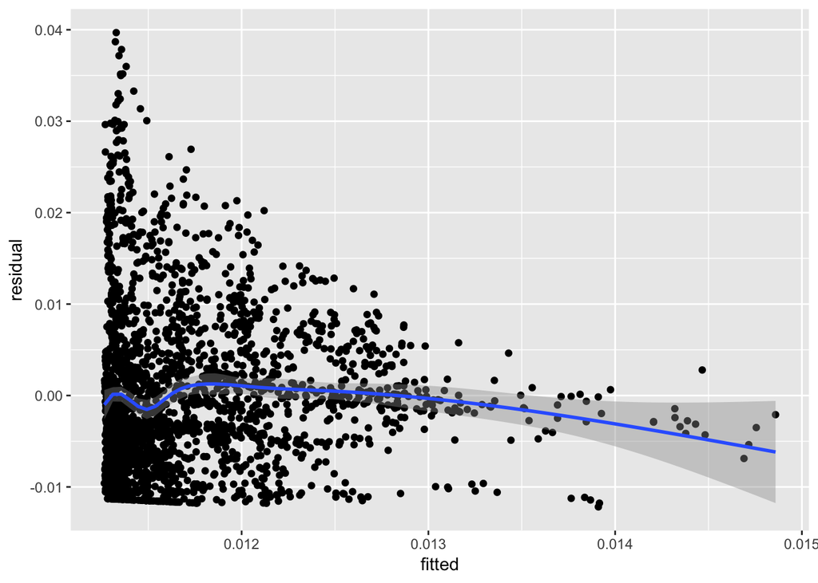

```r
augmented_lin_fit %>%
  ggplot(aes(x=.fitted,y=.resid)) +
    geom_point() +
    geom_smooth() +
    labs(x="fitted", y="residual")
```

We want this to be linear because that indicates a better model. It looks decent, but not great. Indicating we should start looking for other models, but that’s where this tutorial ends!

For way more in depth suicide statistics go here: https://afsp.org/about-suicide/suicide-statistics/